```r
options(repr.plot.width=12, repr.plot.height=6)
Sys.setlocale("LC_TIME", "C")

library(ggplot2)
library(gridExtra)
library(tidyr)
library(dplyr);
```

'C'

# Introdução

O trabalho a seguir monta um modelo de previsão das ações da Google (GOOG), a partir de dados de um período entre 03/12/2017 e 04/12/2022.

Fonte dos dados: https://finance.yahoo.com/quote/GOOG/history?p=GOOG

Método adaptado de PERLIN, M. S. et al. A GARCH Tutorial with R. Revista de Administração Contemporânea Fap UNIFESP (SciELO), 2021. Disponível em: http://dx.doi.org/10.1590/1982-7849rac2021200088

# Pré-processamento

```r
df <- read.csv("GOOG_2017_2022.csv")
df$Date <- as.Date(df$Date, format = "%Y-%m-%d")
head(df)
```

A data.frame: 6 × 7

|  | Date <date> | Open <dbl> | High <dbl> | Low <dbl> | Close <dbl> | Adj.Close <dbl> | Volume <int> |
| --- | --- | --- | --- | --- | --- | --- | --- |
| 1 | 2017-12-04 | 50.6330 | 50.8050 | 49.77850 | 49.9340 | 49.9340 | 38128000 |
| 2 | 2017-12-05 | 49.7970 | 51.0305 | 49.41400 | 50.2575 | 50.2575 | 41346000 |
| 3 | 2017-12-06 | 50.0750 | 51.2485 | 50.05700 | 50.9190 | 50.9190 | 25440000 |
| 4 | 2017-12-07 | 51.0215 | 51.7120 | 50.90355 | 51.5465 | 51.5465 | 29164000 |
| 5 | 2017-12-08 | 51.8745 | 52.1025 | 51.62610 | 51.8525 | 51.8525 | 25816000 |
| 6 | 2017-12-11 | 51.7750 | 52.1900 | 51.60250 | 52.0550 | 52.0550 | 23856000 |

[figure not shown]

```r
ggplot(df, aes(x = Date, y = Close)) +
  geom_line() +
  labs(title = "Google Stock Price 2020-01-01 to 2020-01-31", x = "Date", y = "Adj. CLose")
```

## Dados faltantes

Existem datas faltantes nos dados, que devem ser completadas

```r
df <- df %>%
  mutate(Date = as.Date(Date)) %>%
  complete(Date = seq.Date(min(Date), max(Date), by="day"))

head(df, 10)
```

A tibble: 10 × 7

| Date <date> | Open <dbl> | High <dbl> | Low <dbl> | Close <dbl> | Adj.Close <dbl> | Volume <int> |
| --- | --- | --- | --- | --- | --- | --- |
| 2017-12-04 | 50.6330 | 50.80500 | 49.77850 | 49.9340 | 49.9340 | 38128000 |
| 2017-12-05 | 49.7970 | 51.03050 | 49.41400 | 50.2575 | 50.2575 | 41346000 |
| 2017-12-06 | 50.0750 | 51.24850 | 50.05700 | 50.9190 | 50.9190 | 25440000 |
| 2017-12-07 | 51.0215 | 51.71200 | 50.90355 | 51.5465 | 51.5465 | 29164000 |
| 2017-12-08 | 51.8745 | 52.10250 | 51.62610 | 51.8525 | 51.8525 | 25816000 |
| 2017-12-09 | NA | NA | NA | NA | NA | NA |
| 2017-12-10 | NA | NA | NA | NA | NA | NA |
| 2017-12-11 | 51.7750 | 52.19000 | 51.60250 | 52.0550 | 52.0550 | 23856000 |
| 2017-12-12 | 51.9815 | 52.51550 | 51.68450 | 52.0240 | 52.0240 | 25590000 |
| 2017-12-13 | 52.3060 | 52.33325 | 51.91900 | 52.0305 | 52.0305 | 25654000 |

Sábados e domingos podem ser ignorados porque sempre possuem valores nulos

```r
df <- df[!weekdays(df$Date) %in% c("Saturday", "Sunday"),]
unique(weekdays(df$Date))
```

1. 'Monday'

2. 'Tuesday'

3. 'Wednesday'

4. 'Thursday'

5. 'Friday'

Restam alguns valores nulos (feriados)

```r
holidays <- df$Date[which(is.na(df$Close))]
holidays
```

1. 2017-12-25

2. 2018-01-01

3. 2018-01-15

4. 2018-02-19

5. 2018-03-30

6. 2018-05-28

7. 2018-07-04

8. 2018-09-03

9. 2018-11-22

10. 2018-12-05

11. 2018-12-25

12. 2019-01-01

13. 2019-01-21

14. 2019-02-18

15. 2019-04-19

16. 2019-05-27

17. 2019-07-04

18. 2019-09-02

19. 2019-11-28

20. 2019-12-25

21. 2020-01-01

22. 2020-01-20

23. 2020-02-17

24. 2020-04-10

25. 2020-05-25

26. 2020-07-03

27. 2020-09-07

28. 2020-11-26

29. 2020-12-25

30. 2021-01-01

31. 2021-01-18

32. 2021-02-15

33. 2021-04-02

34. 2021-05-31

35. 2021-07-05

36. 2021-09-06

37. 2021-11-25

38. 2021-12-24

39. 2022-01-17

40. 2022-02-21

41. 2022-04-15

42. 2022-05-30

43. 2022-06-20

44. 2022-07-04

45. 2022-09-05

46. 2022-11-24

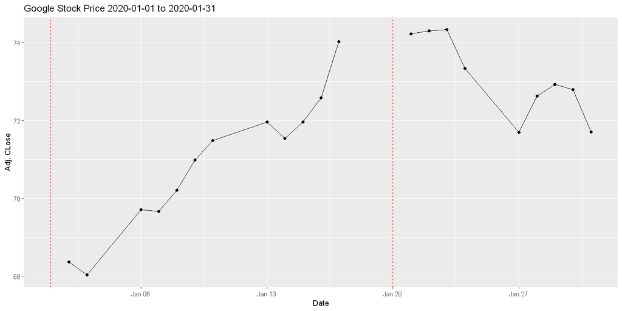

```r
subset <- df[df$Date >= "2020-01-01" & df$Date <= "2020-01-31",]
ggplot(subset, aes(x = Date, y = Close)) +
  geom_line(na.rm=TRUE) +
  geom_point(na.rm=TRUE) +
  geom_vline(xintercept = holidays, linetype = "dashed", color = "red") +
  labs(title = "Google Stock Price 2020-01-01 to 2020-01-31", x = "Date", y = "Adj. CLose")
```

Estes valores nulos podem ser interpolados linearmente, como a média do dia anterior e do dia seguinte, sem impacto significativo no resultado

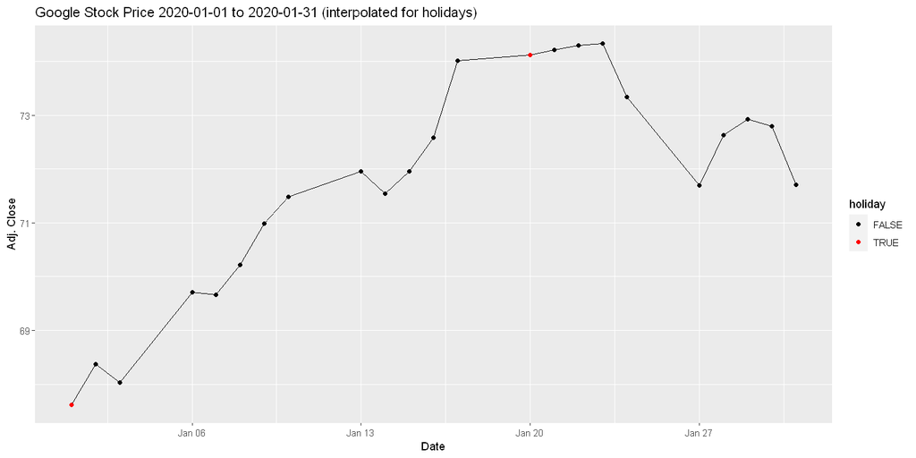

```r
library(zoo)

df <- df %>% mutate(Close = na.approx(Close))

subset <- df[df$Date >= "2020-01-01" & df$Date <= "2020-01-31",]
subset <- subset %>% mutate(holiday = Date %in% holidays)
ggplot(subset, aes(x = Date, y = Close)) +
    geom_line() +
    geom_point(aes(color = holiday)) +
    scale_color_manual(values = c("black", "red")) +
    labs(x = "Date", y = "Adj. Close", title = "Google Stock Price 2020-01-01 to 2020-01-31 (interpolated for holidays)")
```

# Diagnóstico da série

Primeiramente, tomamos a série de retornos, por ser estacionária e ergódica.

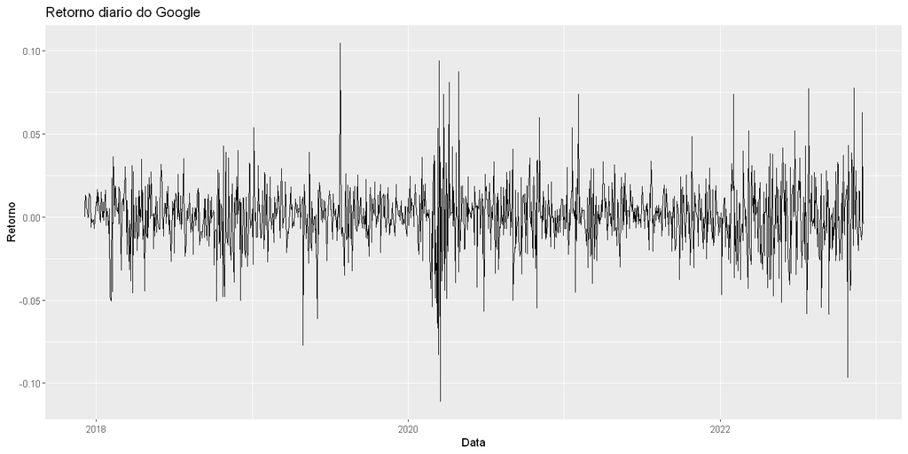

```r
df$ret <- (df$Close - lag(df$Close)) / lag(df$Close)
df$ret[1] <- 0
retplot <- ggplot(df, aes(x = Date, y = ret)) +
    geom_line() +
    labs(x = "Data", y = "Retorno", title = "Retorno diario do Google")

retplot
```

A série de retornos possui picos e vales de diferentes tamanhos. Isso indica heteroscedasticidade da série, ou seja, a variância não é constante. Podemos utilizar o teste dos multiplicadores de Lagrange para refutar ou confirmar essa hipótese.

```r
library(dynlm)
library(FinTS)

# Modela a média
df.mean <- dynlm(df$ret ~ 1)
# Resíduos quadrados
ehatsq <- ts(resid(df.mean)^2)
# Regressão em resíduos quadrados defasados
df.ARCH <- dynlm(ehatsq ~ L(ehatsq))

df.archTest <- ArchTest(df$ret, lags = 1, demean = TRUE)
df.archTest
```

```
	ARCH LM-test; Null hypothesis: no ARCH effects

data:  df$ret
Chi-squared = 64.897, df = 1, p-value = 7.893e-16
```

O valor-p do teste é $< 0.05$, portanto rejeita-se a hipótese nula de que a série não possui efeitos de um ARCH.

Transformar uma série em uma série de retornos torna seus pontos são não-correlacionados, restando somente a variância, o que torna-as adequadas para uso em um modelo GARCH. Podemos comprovar este fato observando que o autocorrelograma da série não possui valores elevados.

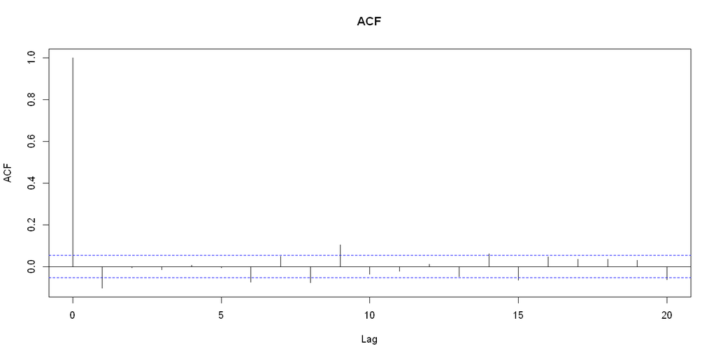

```r
acf(df$ret, lag.max = 20, main = "ACF")
```

# Encontrando o melhor modelo

Primeiramente, devemos estimar vários modelos por meio da combinação de diferentes parâmetros.

```r
library(rugarch)

# Função que ajusta um modelo GARCH com os parâmetros passados
fit_garch <- function(
        x,
        ar_lag,
        ma_lag,
        arch_lag,
        garch_lag,
        model_type,
        distribution_type
) {
    spec <- ugarchspec(variance.model = list(model = model_type, garchOrder = c(arch_lag, garch_lag)),
                       mean.model = list(armaOrder = c(ar_lag, ma_lag)),
                       distribution.model = distribution_type
    )

    model_name <- paste0('ARMA(', ar_lag, ',', ma_lag, ')+', model_type,
        '(', arch_lag, ',', garch_lag, ') ', distribution_type)
    # message('Estimando modelo ', model_name, '...')

    try ({
        fit <- ugarchfit(spec = spec, data = x)
    })
    if (!is.null(coef(fit))) {
        AIC <- rugarch::infocriteria(fit)[1]
        BIC <- rugarch::infocriteria(fit)[2]
    } else {
        # Estimativa falhou
        AIC <- NA
        BIC <- NA
    }

    est_tab <- tibble(ar_lag,
                      ma_lag,
                      arch_lag,
                      garch_lag,
                      AIC =  AIC,
                      BIC = BIC,
                      model_type = model_type,
                      distribution_type,
                      model_name = model_name)
    return(est_tab)
}

# Define todas as combinações de parâmetros
max_lag_AR <- 1
max_lag_MA <- 1
max_lag_ARCH <- 2
max_lag_GARCH <- 1
dist_to_use <- c('norm', 'std')
models_to_estimate <- c('sGARCH', 'eGARCH', 'gjrGARCH')
grid = expand_grid(ar_lag = 0:max_lag_AR,
                   ma_lag = 0:max_lag_MA,
                   arch_lag = 1:max_lag_ARCH,
                   garch_lag = 1:max_lag_GARCH,
                   model_type = models_to_estimate,
                   distribution_type = dist_to_use)

library(purrr)

# Estima todos os modelos
results <- pmap(.l = list(x = rep(list(df$ret), nrow(grid)),
                          ar_lag = grid$ar_lag,
                          ma_lag = grid$ma_lag,
                          arch_lag = grid$arch_lag,
                          garch_lag = grid$garch_lag,
                          model_type = grid$model_type,
                          distribution_type = grid$distribution_type),
                fit_garch)
```

Agora, devemos escolher o melhor modelo. Podemos considerar dois criérios: o AIC, que tende a escolher modelos com mais parâmetros, e o BIC, que penaliza a quantidade de coeficientes.

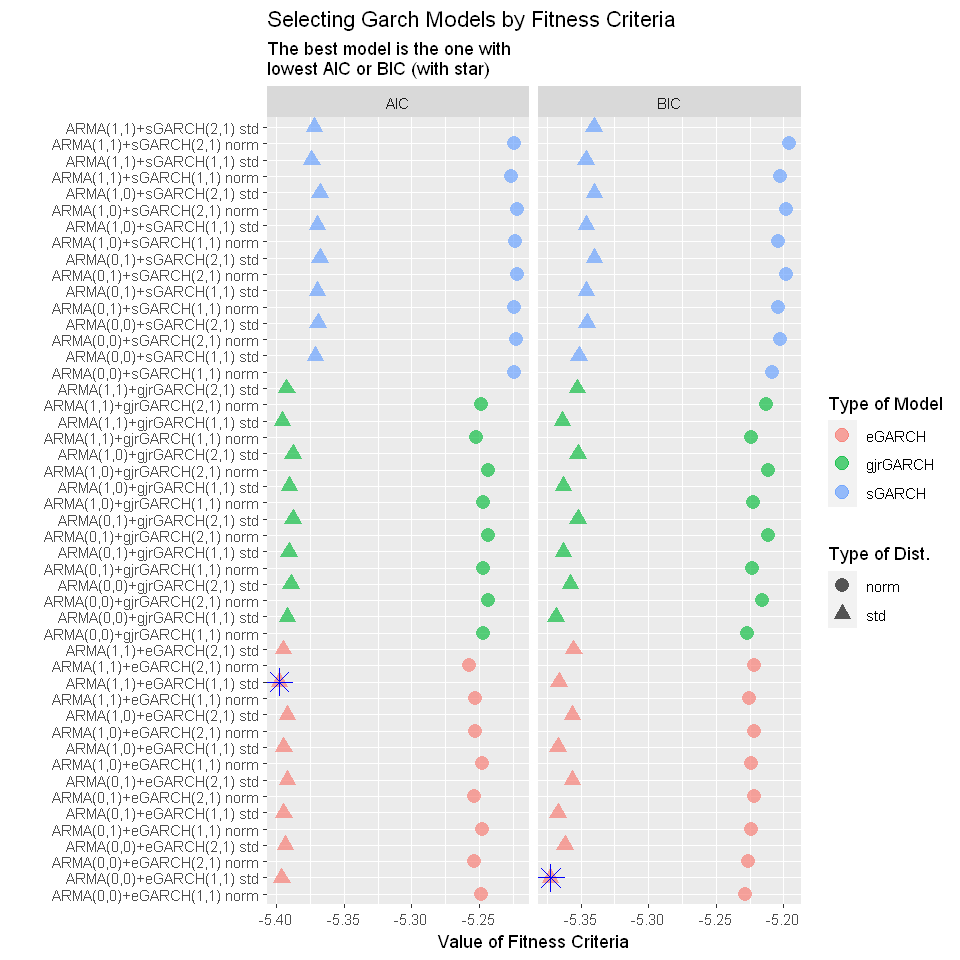

```r
tab_results <- bind_rows(results)

# Tabela pivot (melhor para plotar)
df_long <- tidyr::pivot_longer(data = tab_results %>% select(model_name,
                                                             model_type,
                                                             distribution_type,
                                                             AIC, BIC),
                               cols = c('AIC', 'BIC'))

models_names <- unique(df_long$model_name)
best_models <- c(tab_results$model_name[which.min(tab_results$AIC)],
                 tab_results$model_name[which.min(tab_results$BIC)])

# Encontrar os melhores modelos
df_long <- df_long %>%
    mutate(order_model = if_else(model_name %in% best_models, 'Best Model', 'Not Best Model') ) %>%
    na.omit()

# Fazer tabela com os melhores modelos
df_best_models <- df_long %>%
    group_by(name) %>%
    summarise(model_name = model_name[which.min(value)],
                value = value[which.min(value)],
                model_type = model_type[which.min(value)])

# Plotar resultados
options(repr.plot.width=8, repr.plot.height=8)
ggplot(df_long %>% arrange(model_type), aes(x = reorder(model_name, order(model_type)),
                                            y = value,
                                            shape = distribution_type,
                                            color = model_type)) +
    geom_point(size = 3.5, alpha = 0.65) +
    coord_flip() +
    facet_wrap(~name, scales = 'free_x') +
    geom_point(data = df_best_models,
               mapping = aes(x = reorder(model_name, order(model_type)), y = value),
               color = 'blue', size = 5, shape = 8) +
    labs(title = 'Selecting Garch Models by Fitness Criteria',
         subtitle = 'The best model is the one with \nlowest AIC or BIC (with star)',
         x = '',
         y = 'Value of Fitness Criteria',
         shape = 'Type of Dist.',
         color = 'Type of Model') +
    theme(legend.position = "right")
```

Vemos que os melhores modelos de acordo com os critérios AIC e BIC são, respectivamente, ARMA(1, 1) + eGARCH(1, 1) com a distribuição de Student, e ARMA(0, 0) + eGARCH(1, 1) com a distribuição de Student.

Além disso, existe uma clara discrepância entre a qualidade do ajuste de modelos com a distribuição Normal e Student, muito maior do que as entre tipos de modelo e lags da média e da variância escolhidos, mostrando que a escolha da distribuição é muito importante para selecionar um GARCH através da AIC e da BIC.

# Simulando os modelos

```r
model.spec <- ugarchspec(
    variance.model = list(model = "eGARCH", garchOrder = c(1, 1)),
    mean.model = list(armaOrder = c(1, 1)),
    distribution.model = "std"
)
model.fit <- ugarchfit(spec = model.spec, data = df$ret)
```

Em seguida, realizamos 5000 simulações do para os próximos três anos.

```r
simulate <- function(data, n_sim, n_days_ahead, model) {

    single_sim <- function(i_sim, n_days_ahead, model) {
        rugarch_sim = ugarchsim(model, n.sim = n_days_ahead, m.sim = 1)
        sim_series <- rugarch_sim@simulation$seriesSim
        sim <- tibble(
            i_sim = i_sim,  # Id da simulação
            i_t = 0:length(sim_series),  # Index da previsão
            date = last(data$Date) + i_t,  # Data da previsão
            sim_ret = c(0, sim_series),  # Retorno simulado
            sim_price = last(data$Close) * (cumprod(1 + sim_ret))  # Preço simulado
        )
        return(sim)
    }

    # Realiza as simulações
    out <- bind_rows(
        map(.x = 1:n_sim,
            .f = single_sim,
            n_days_ahead = n_days_ahead,
            model = model
        )
    )

    return(out)
}

n_sim <- 5000
n_days_ahead <- 3*365
model.sim <- simulate(df, n_sim, n_days_ahead, model.fit)
glimpse(model.sim)
```

```
Rows: 5,480,000
Columns: 5
$ i_sim     <int> 1, 1, 1, 1, 1, 1, 1, 1, 1, 1, 1, 1, 1, 1, 1, 1, 1, 1, 1, 1, …
$ i_t       <int> 0, 1, 2, 3, 4, 5, 6, 7, 8, 9, 10, 11, 12, 13, 14, 15, 16, 17…
$ date      <date> 2022-12-02, 2022-12-03, 2022-12-04, 2022-12-05, 2022-12-06,…
$ sim_ret   <dbl> 0.0000000000, 0.0061973092, 0.0091507377, -0.0410275418, -0.…
$ sim_price <dbl> 100.83000, 101.45488, 102.38326, 98.18273, 95.45067, 94.5424…
```

Podemos visualizar o resultado das simulações ao plotar as linhas. Quanto maior a densidade das linhas em uma região, maior a probabilidade de que o valor das ações estará nessa região no tempo determinado.

[figure not shown]

```r
ggplot() +
    geom_line(data = df,
            aes(x = Date, y = Close),
            color = "black",
            linewidth = 0.75,
            na.rm=TRUE)  +
    geom_line(data = model.sim,
            aes(x = date, y = sim_price, group = i_sim),
            color = "grey",
            linewidth = 0.25,
            alpha = 0.03,
            na.rm=TRUE) +
    geom_hline(yintercept = max(df$Close)) +
    labs(title = "Price Projections of Google Stock (GOOG)",
        subtitle = paste0("Total of ", n_sim, " simulations based on an ARMA+eGARCH model selected by BIC"),
        caption = "Data from Yahoo Finance",
        x = "",
        y = "Value") +
    ylim(c(0.75*min(df$Close), 1.25*max(df$Close))) +
    xlim(c(min(df$Date), max(df$Date) + n_days_ahead))
```

Também podemos calcular certas probabilidades. Neste caso, calcularei a probabilidade do valor das ações retornar ao pico histórico de ~US$150.00 de 2021.

[figure not shown]

```r
tab_prob <- model.sim %>%
    group_by(date) %>%
      summarise(prob = mean(sim_price > max(df$Close)))

df_date <- tibble(idx = c(first(which(tab_prob$prob > 0.001)),
                          first(which(tab_prob$prob > 0.5)),
                          first(which(tab_prob$prob > 0.75)),
                          first(which(tab_prob$prob > 0.90))),
                  date = tab_prob$date[idx],
                  prob = tab_prob$prob[idx],
                  my_text = paste0(format(date, '%d/%m/%Y'), '\nprob = ', scales::percent(prob) ) )

ggplot(tab_prob, aes(x = date, y = prob) ) +
  geom_line(size = 2) +
  labs(title = paste0('Probabilities of Google Stock (GOOG) to be above US$ ', max(df$Close)),
       subtitle = 'Calculations based on simulations of an ARMA+eGARCH model selected by BIC',
       x = '',
       y = 'Probability') +
  geom_point(data = df_date,
             aes(x = date, y = prob), size = 5, color = 'red') +
  geom_text(data = df_date, aes(x = date, y = prob, label = my_text),
            nudge_x = nrow(tab_prob)*0.085,
            nudge_y = -0.05,
            color ='red', check_overlap = TRUE)
```

Vemos que, de acordo com o modelo e com base nos dados históricos das ações do Google, só podemos ter mais de 90% de certeza de que o valor das ações retornará ao pico de 2021 após mais de dois anos.

# Conclusão

Nenhum modelo é capaz de considerar todas as imprevisibilidades do mercado financeiro, e portanto este modelo é limitado em sua capacidade de previsão, ainda mais para um período de três anos, em que diversos eventos podem mudar a tendência do valor das ações (como quando a pandemia de COVID-19 visivelmente influenciou no crescimento das ações entre 2020 e 2021).

Tendo isso em mente, podemos colocar um bom grau de confiança em uma informação que o resultado deste modelo nos providencia: no cenário atual, existe uma boa chance de que as ações da Google retornarão ao seu pico de 2021 entre um ou dois anos a partir de hoje.